# oca_supp_rearrest

Stephen Koppel

2023-01-27

```r
# install packages

packages <- c("tidyverse", "dplyr", "lubridate", "readr", "ggplot2")
lapply(packages, library, character.only = TRUE)
```

[output not shown]

```r
# clear environment

rm(list = ls())
graphics.off()
```

```r
# read in

OCA <- read_csv("Data/OCA_supp.csv")
OCA
```

```
## # A tibble: 562,646 × 111
##     caseid arr_age arr_sex arr_r…¹ arr_e…² arr_yr arr_mo arr_a…³ arr_c…⁴ arr_r…⁵
##      <dbl>   <dbl> <chr>   <chr>   <chr>    <dbl>  <dbl> <chr>   <chr>   <chr>
##  1  770108      19 Male    White   Not Hi…   1981      1 NYCPD … New Yo… New Yo…
##  2 1020668      41 Male    White   Not Hi…   1983      7 Coloni… Albany  Upstate
##  3  723330      37 Male    Black   Not Hi…   1998      1 NYCPD … Bronx   New Yo…
##  4  649470      23 Male    Black   Not Hi…   1997     12 NYCPD … Bronx   New Yo…
##  5  587563      26 Male    Unknown Hispan…   1997      2 NYCPD … New Yo… New Yo…
##  6  771273      22 Male    Black   Not Hi…   1994     10 NYCPD … New Yo… New Yo…
##  7  612054      18 Female  Unknown Hispan…   1994     10 NYCPD … New Yo… New Yo…
##  8  755562      19 Female  Black   Not Hi…   1994     10 NYCPD … New Yo… New Yo…
##  9  888194      28 Female  Unknown Hispan…   1994      9 NYCPD … Kings   New Yo…
## 10 1071415      24 Male    Unknown Hispan…   1994      4 NYCPD … Queens  New Yo…
## # … with 562,636 more rows, 101 more variables: arr_charge <chr>,
## #   arr_class <chr>, arr_attempt <chr>, arr_vfo <chr>, arr_firearm <chr>,
## #   arr_hate <chr>, arrest_type <chr>, crime_age <dbl>, crime_yr <dbl>,
## #   crime_mo <dbl>, larg_yr <dbl>, larg_mo <dbl>, larg_charge <chr>,
## #   larg_class <chr>, larg_attempt <chr>, larg_vfo <chr>, larg_firearm <chr>,
## #   larg_hate <chr>, uarg_yr <dbl>, uarg_mo <dbl>, uarg_charge <chr>,
## #   uarg_class <chr>, uarg_attempt <chr>, uarg_vfo <chr>, uarg_firearm <chr>, …
```

```r
# create binary vfo flag

OCA <- OCA %>%
  mutate(arraign_vfo = case_when (larg_vfo != "Not VFO" ~ "VFO",
                               TRUE ~ larg_vfo))

OCA %>%
  mutate(arraign_vfo = if_else(larg_vfo != "Not VFO", "VFO", "Not VFO"))
```

```
## # A tibble: 562,646 × 112
##     caseid arr_age arr_sex arr_r…¹ arr_e…² arr_yr arr_mo arr_a…³ arr_c…⁴ arr_r…⁵
##      <dbl>   <dbl> <chr>   <chr>   <chr>    <dbl>  <dbl> <chr>   <chr>   <chr>
##  1  770108      19 Male    White   Not Hi…   1981      1 NYCPD … New Yo… New Yo…
##  2 1020668      41 Male    White   Not Hi…   1983      7 Coloni… Albany  Upstate
##  3  723330      37 Male    Black   Not Hi…   1998      1 NYCPD … Bronx   New Yo…
##  4  649470      23 Male    Black   Not Hi…   1997     12 NYCPD … Bronx   New Yo…
##  5  587563      26 Male    Unknown Hispan…   1997      2 NYCPD … New Yo… New Yo…
##  6  771273      22 Male    Black   Not Hi…   1994     10 NYCPD … New Yo… New Yo…
##  7  612054      18 Female  Unknown Hispan…   1994     10 NYCPD … New Yo… New Yo…
##  8  755562      19 Female  Black   Not Hi…   1994     10 NYCPD … New Yo… New Yo…
##  9  888194      28 Female  Unknown Hispan…   1994      9 NYCPD … Kings   New Yo…
## 10 1071415      24 Male    Unknown Hispan…   1994      4 NYCPD … Queens  New Yo…
## # … with 562,636 more rows, 102 more variables: arr_charge <chr>,
## #   arr_class <chr>, arr_attempt <chr>, arr_vfo <chr>, arr_firearm <chr>,
## #   arr_hate <chr>, arrest_type <chr>, crime_age <dbl>, crime_yr <dbl>,
## #   crime_mo <dbl>, larg_yr <dbl>, larg_mo <dbl>, larg_charge <chr>,
## #   larg_class <chr>, larg_attempt <chr>, larg_vfo <chr>, larg_firearm <chr>,
## #   larg_hate <chr>, uarg_yr <dbl>, uarg_mo <dbl>, uarg_charge <chr>,
## #   uarg_class <chr>, uarg_attempt <chr>, uarg_vfo <chr>, uarg_firearm <chr>, …
```

```r
#inspect

OCA %>%
  count(arraign_vfo, larg_vfo)
```

```
## # A tibble: 5 × 3
##   arraign_vfo larg_vfo                         n
##   <chr>       <chr>                        <int>
## 1 Not VFO     Not VFO                     492482
## 2 VFO         Underlying VFO Charge         1727
## 3 VFO         VFO                          64425
## 4 VFO         VFO-like class A-1 offenses   1246
## 5 <NA>        <NA>                          2766
```

```r
# make charges/subcharges flaggable

OCA <- OCA %>%
  mutate(larg_charge = str_squish(toupper(larg_charge))) %>% # squish out whitespace and upper case
  mutate(arraign_charge = str_sub(larg_charge, 4,9)) %>% # extract charge
  mutate(arraign_subcharge = str_sub(larg_charge, 4,12)) %>%  # extract with sub
  mutate(arraign_subcharge = str_trim(arraign_subcharge, side="right")) %>% # trim ws
  mutate(article = str_sub(arraign_charge,1,3))

# inspect

OCA %>%
  select(arraign_charge, arraign_subcharge, article) %>%
  View()
```

```r
# make date

OCA <- OCA %>%
  mutate(arraign_date = make_date(larg_yr, larg_mo))

OCA %>%
  select(larg_yr, larg_mo, arraign_date) %>%
  View()
```

# flag bail-eligible charges

# Text below from Senate bill S1509C, enacting the initial Bail Elimination Act of 2019.

# A principal stands charged with a qualifying offense for the purposes of this subdivision when he or she stands charged with:

# (a) a felony enumerated in section 70.02 of the penal law, other than burglary in the second degree as defined in subdivision two of section 140.25 of the penal law or robbery in the second degree as defined in subdivision one of section 160.10 of the penal law;

# (b) a crime involving witness intimidation under section 215.15 of the penal law;

# (c) a crime involving witness tampering under section 215.11, 215.12 or 215.13 of the penal law;

# (d) a class A felony defined in the penal law, other than in article two hundred twenty of such law with the exception of section 220.77 of such law;

# (e) a felony sex offense defined in section 70.80 of the penal law or a crime involving incest as defined in section 255.25, 255.26 or 255.27 of such law, or a misdemeanor defined in article one hundred thirty of such law;

# (f) conspiracy in the second degree as defined in section 105.15 of the penal law, where the underlying allegation of such charge is that the defendant conspired to commit a class A felony defined in article one hundred twenty-five of the penal law;

# (g) money laundering in support of terrorism in the first degree as defined in section 470.24 of the penal law; money laundering in support of terrorism in the second degree as defined in section 470.23 of the penal law; or a felony crime of terrorism as defined in article four hundred ninety of the penal law, other than the crime defined in section 490.20 of such law;

# (h) criminal contempt in the second degree as defined in subdivision three of section 215.50 of the penal law, criminal contempt in the first degree as defined in subdivision (b), (c) or (d) of section 215.51 of the penal law or aggravated criminal contempt as defined in section 215.52 of the penal law, and the underlying allegation of such charge of criminal contempt in the second degree, criminal contempt in the first degree or aggravated criminal contempt is that the defendant violated a duly served order of protection where the protected party is a member of the defendant’s same family or household as defined in subdivision one of section 530.11 of this article; or

# (i) facilitating a sexual performance by a child with a controlled substance or alcohol as defined in section 263.30 of the penal law, use of a child in a sexual performance as defined in section 263.05 of the penal law or luring a child as defined in subdivision one of section 120.70 of the penal law.

```r
OCA <- OCA %>%
  mutate(bail_eligible = case_when
         (arraign_vfo == "VFO" & !arraign_subcharge %in% c("140.25 02", "160.10 01") ~ "a",
           arraign_charge == "215.15" ~ "b",
           arraign_charge %in% c("215.11","215.12","215.13") ~ "c",
           arraign_charge %in% c("460.20","125.26","150.20","105.17","490.25","490.45","490.55","135.25","125.27","125.25","220.77", "490.50","130.95","130.96") ~ "d",  #some redundancy here as A-1 already included in VFO flag
           article == "130" | arraign_charge %in% c("255.25", "255.26", "255.27", "230.06") ~ "e",
           arraign_charge %in% c("470.23","470.24","490.10","490.15","490.25","490.30","490.35","490.37","490.40","490.45","490.47","490.50","490.55") ~ "g",
           arraign_subcharge %in% c("215.50 03", "215.51 B", "215.51 BI","215.51 BV", "215.51 C", "215.51 D") ~ "h",
           arraign_charge %in% c("263.30", "263.05") | arraign_subcharge == "120.70 01" ~ "i"))

# Flag any bail-eligible charge

OCA <- OCA %>%
  mutate(bail_eligible_flag = ifelse(bail_eligible %in% c("a","b","c","d","e","g","h","i"),
                                     "Yes", "No"))

# Inspect bail ineligible cases missed by flag (ie, bail ineligible but bailed). These will be later excluded.

OCA %>%
  filter((arr_region =="New York City"),
         (arraign_date >="2020-01-01" & arraign_date <="2020-06-01"),
         (larg_rel_decision != "Disposed at arraign" & !is.na(larg_rel_decision)),
         (!larg_bail_amount %in% 1:5),
         (bail_eligible_flag=="No" & larg_rel_decision=="Bail-Set")) %>%
          View()

# 426 where flag missed bail-eligibility post-reform; these will be excluded from analysis
```

```r
# indicator for any rearrest with 180 days

OCA <- OCA %>%
  mutate(any_rearrest_180 = ifelse(rearr_vfo_180 == "Yes"
                                   | rearr_nonvfo_180 == "Yes"
                                   | rearr_misd_180 == "Yes",
                                   "Yes", "No"))
```

```r
# indicator for any rearrest within the tracked period

OCA <- OCA %>%
  mutate(any_rearrest = ifelse(rearr_vfo == "Yes"
                               | rearr_nonvfo == "Yes"
                               | rearr_misd == "Yes",
                               "Yes", "No"))
```

```r
# generate summary stats for any rearrest within 180 by eligibility


OCA %>%
  filter(
    (arr_region =="New York City"
     & arraign_date >="2019-01-01"
     & arraign_date <="2020-06-01"
     & larg_rel_decision != "Disposed at arraign"
     & !is.na(larg_rel_decision)
     & !larg_bail_amount %in% 1:5)
    & (!(arraign_date >= "2020-01-01" & arraign_date<= "2020-06-01" & larg_rel_decision == "Bail-Set" & bail_eligible_flag =="No"))
  ) %>%
  group_by(arraign_date, bail_eligible_flag, any_rearrest_180) %>%
  summarise(N= n()) %>%
  mutate(percent_rearrested_180 = N/sum(N) * 100) %>%
  filter(any_rearrest_180 == "Yes") %>%
  pivot_wider(id_cols = arraign_date, names_from = bail_eligible_flag, values_from = percent_rearrested_180)
```

```
## can override using the `.groups` argument.
```

```
## # A tibble: 18 × 3
## # Groups:   arraign_date [18]
##    arraign_date    No   Yes
##    <date>       <dbl> <dbl>
##  1 2019-01-01    19.9  18.5
##  2 2019-02-01    19.5  20.5
##  3 2019-03-01    20.0  21.8
##  4 2019-04-01    19.5  19.9
##  5 2019-05-01    20    19.2
##  6 2019-06-01    20.4  20.9
##  7 2019-07-01    19.9  18.7
##  8 2019-08-01    19.8  18.2
##  9 2019-09-01    18.5  18.0
## 10 2019-10-01    17.5  16.2
## 11 2019-11-01    17.2  18.0
## 12 2019-12-01    19.0  19.0
## 13 2020-01-01    20.6  21.7
## 14 2020-02-01    22.6  19.7
## 15 2020-03-01    23.1  21.2
## 16 2020-04-01    28.3  23.9
## 17 2020-05-01    26.4  21.7
## 18 2020-06-01    20.3  20.7
```

```
## can override using the `.groups` argument.
```

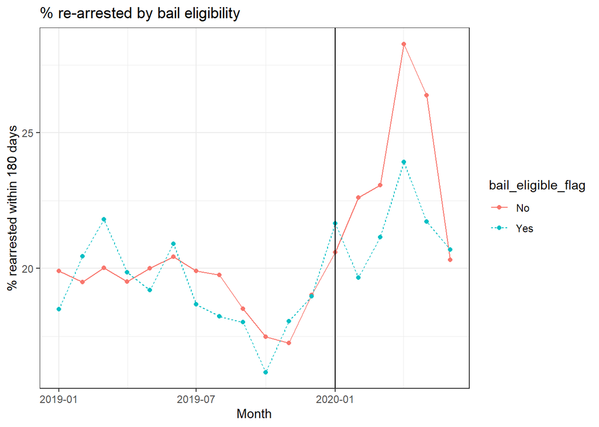

```r
# plot any rearrest within 180

OCA %>%
  filter(
    (arr_region =="New York City"
     & arraign_date >="2019-01-01"
     & arraign_date <="2020-06-01"
     & larg_rel_decision != "Disposed at arraign"
     & !is.na(larg_rel_decision)
     & !larg_bail_amount %in% 1:5)
    & (!(arraign_date >= "2020-01-01" & arraign_date<= "2020-06-01" & larg_rel_decision == "Bail-Set" & bail_eligible_flag =="No"))
  ) %>%
  group_by(arraign_date, bail_eligible_flag, any_rearrest_180) %>%
  summarise(N= n()) %>%
  mutate(percent_rearrested_180 = N/sum(N) * 100) %>%
  filter(any_rearrest_180 == "Yes") %>%
  ggplot(aes(x = arraign_date,
             y = percent_rearrested_180,
             group=bail_eligible_flag,
             color=bail_eligible_flag))+
  geom_line(aes(linetype=bail_eligible_flag)) + geom_point() + theme_bw() +
  ggtitle("% re-arrested by bail eligibility") +
  xlab("Month") + ylab("% rearrested within 180 days") + geom_vline(xintercept = as.numeric(as.Date("2020-01-01")))
```

```r
OCA %>%
  filter(
    (arr_region =="New York City"
     & arraign_date >="2019-01-01"
     & arraign_date <="2020-06-01"
     & larg_rel_decision != "Disposed at arraign"
     & !is.na(larg_rel_decision)
     & !larg_bail_amount %in% 1:5)
     & (!(arraign_date >= "2020-01-01" & arraign_date<= "2020-06-01" & larg_rel_decision == "Bail-Set" & bail_eligible_flag =="No"))
        ) %>%
  group_by(arraign_date, bail_eligible_flag, any_rearrest) %>%
  summarise(N = n()) %>%
  mutate(percent_rearrested = N/sum(N) * 100) %>%
  filter(any_rearrest == "Yes") %>%
  pivot_wider(id_cols = arraign_date, names_from = bail_eligible_flag, values_from = percent_rearrested)
```

```
## can override using the `.groups` argument.
```

```
## # A tibble: 18 × 3
## # Groups:   arraign_date [18]
##    arraign_date    No   Yes
##    <date>       <dbl> <dbl>
##  1 2019-01-01    23.9  25.0
##  2 2019-02-01    23.5  26.6
##  3 2019-03-01    24.0  27.3
##  4 2019-04-01    23.8  26.6
##  5 2019-05-01    23.6  26.1
##  6 2019-06-01    24.5  26.5
##  7 2019-07-01    23.4  26.6
##  8 2019-08-01    23.8  26.3
##  9 2019-09-01    22.4  26.3
## 10 2019-10-01    21.6  25.3
## 11 2019-11-01    21.3  27.7
## 12 2019-12-01    23.7  27.5
## 13 2020-01-01    27.1  33.1
## 14 2020-02-01    30.0  32.4
## 15 2020-03-01    32.1  35.2
## 16 2020-04-01    34.9  37.8
## 17 2020-05-01    33.6  34.0
## 18 2020-06-01    26.4  33.6
```

```
## can override using the `.groups` argument.
```

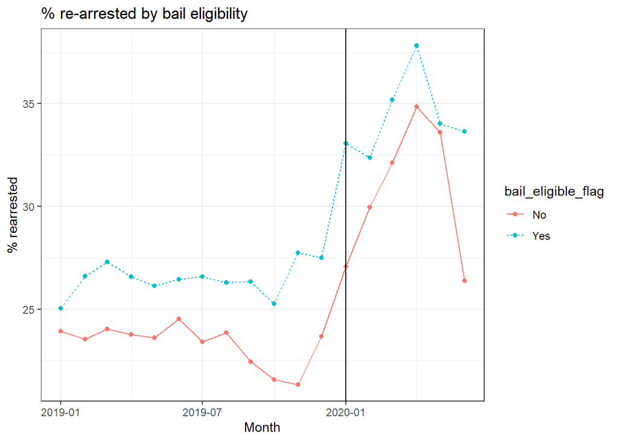

```r
# generate summary stats for any re-arrest by elibility


# plot any re-arrest

OCA %>%
  filter(
    (arr_region =="New York City"
     & arraign_date >="2019-01-01"
     & arraign_date <="2020-06-01"
     & larg_rel_decision != "Disposed at arraign"
     & !is.na(larg_rel_decision)
     & !larg_bail_amount %in% 1:5)
     & (!(arraign_date >= "2020-01-01" & arraign_date<= "2020-06-01" & larg_rel_decision == "Bail-Set" & bail_eligible_flag =="No"))
        ) %>%
  group_by(arraign_date, bail_eligible_flag, any_rearrest) %>%
  summarise(N= n()) %>%
  mutate(percent_rearrested = N/sum(N) * 100) %>%
  filter(any_rearrest == "Yes") %>%
  ggplot(aes(x = arraign_date,
             y = percent_rearrested,
             group=bail_eligible_flag,
             color=bail_eligible_flag))+
  geom_line(aes(linetype=bail_eligible_flag)) + geom_point() + theme_bw() +
  ggtitle("% re-arrested by bail eligibility") +
  xlab("Month") + ylab("% rearrested") + geom_vline(xintercept = as.numeric(as.Date("2020-01-01")))
```